# Economic and Health Impact of Storm Events

Rich Doan

March 20, 2015

## Synopsis

This report provides an overview of the types of weather events that have historically been the most costly and the most harmful in the U.S. Costliness has been determined by the sum of property damage and crop damage. Harmfulness to health has been determined by the sum of fatalities and injuries, collectively referred to here as “casualties.” I will examine weather events over the period 1996-2011 and show which ten events have been the most costly and most dangerous. The purpose of the analysis is to understand what types of events, relatively speaking, are the most costly and dangerous, for the purpose of public policy. The ten events and their relative impacts, for both cost and danger, can be seen in the results below.

## Data Processing

### Loading and reading the data

The data was in a zipped csv file loaded from a National Weather Service server. It was read into a data frame.

```r
fileurl = "https://d396qusza40orc.cloudfront.net/repdata%2Fdata%2FStormData.csv.bz2"
download.file(url=fileurl, destfile="StormData.csv.bz2", method="curl")
data.raw <- read.csv("StormData.csv.bz2")
data.a <- data.raw   # make copy to manipulate
```

### Select observations from 1996 on

The NWS data includes observations from 1950 to 2011. However, the criteria for data collection has changed over that time period. Starting in 1996, NWS has collected data on 48 types of events, up from 3 types of events in the previous 28 years. This analysis will only consider events starting in 1996. For more information on monitored event types, see the following url: http://www.ncdc.noaa.gov/stormevents/details.jsp?type=eventtype.

```r
data.a$date <- strptime(data.a$BGN_DATE, "%m/%d/%Y")
data.a <- subset(data.a, data.a$date >= strptime("1/1/1996", "%m/%d/%Y"))
```

### Compute total casualties and total damage

```r
### multiply listed damage value by factor
mult <- function(x, exp) {
    if (exp == "K")
        return(x * 1000)
    if (exp == "M")
        return(x * 1e+06)
    if (exp == "B")
        return(x * 1e+09)
    return(x)
}
data.a$pdmg <- mapply(mult, data.a$PROPDMG, data.a$PROPDMGEXP)  # compute property damage
data.a$cdmg <- mapply(mult, data.a$CROPDMG, data.a$CROPDMGEXP)  # compute crop damage
data.a$tdmg <- data.a$pdmg + data.a$cdmg                          # compute total damage
data.a$casualties <- data.a$FATALITIES + data.a$INJURIES
data.a <- subset(data.a, tdmg > 0 | casualties > 0)     # ignore rows with no casualties and damage
```

### Correcting anomalous values in Napa events

```r
## correct data for Napa Flood, rows 567251, 605953
data.a["567251", "PROPDMG"] <- 0
data.a["567251", "CROPDMG"] <- 0
data.a["567251", "PROPDMGEXP"] <- "0"
data.a["567251", "CROPDMGEXP"] <- "0"
data.a["605953", "PROPDMGEXP"] <- "M"
```

### Cleaning EVTYPE

The data are to be analyzed by type of event. The type of event is found in the field *EVTYPE*.

```r
unique <- length(unique(data.a$EVTYPE))
unique
```

```
## [1] 222
```

The observations that have either damage or casualties contain 222 distinct values for EVTYPE.

#### Simple corrections of EVTYPE

The guidelines for categorizing events are in “Storm Data Preparation,” (“SDP”) found at https://d396qusza40orc.cloudfront.net/repdata%2Fpeer2_doc%2Fpd01016005curr.pdf. The SDP specifies 48 types of events. The approach in this report is to match as many of the 222 distinct values to the 48 SDP values as possible. If the 222 values contain some or all of the 48 types as listed in the SDP, at least 174 values do not match the SDP list. I will assume that many of the unmatched values can be straightforwardly matched to the 48 SDP values, using the following principles.

1. Some values match the SDP when extra characters or symbols are removed (e.g., “hail 175”).
2. Some values match the SDP when different forms of words are exchanged (e.g., “WINDS” for “WIND”, “FLOODING” for “FLOOD”).
3. Abbrevations of words are replaced with nonabbreviated words (e.g., “TSTM” for “THUNDERSTORM”).

“Corrections” of the EVTYPE field were then made with regular expressions.

```r
data.a$EVTYPE <- toupper(data.a$EVTYPE)
data.a$EVTYPE <- gsub("WINDS", "WIND", data.a$EVTYPE)
data.a$EVTYPE <- gsub("RAINS", "RAIN", data.a$EVTYPE)
data.a$EVTYPE <- gsub("HAIL [0-9].*", "HAIL", data.a$EVTYPE)
data.a$EVTYPE <- gsub("TSTM", "THUNDERSTORM", data.a$EVTYPE)
data.a$EVTYPE <- gsub("THUNDERSTORMS", "THUNDERSTORM", data.a$EVTYPE)
data.a$EVTYPE <- gsub("FLOODING", "FLOOD", data.a$EVTYPE)
data.a$EVTYPE <- gsub("FLOODS", "FLOOD", data.a$EVTYPE)
data.a$EVTYPE <- gsub("TROPICAL STORM.*", "TROPICAL STORM", data.a$EVTYPE)
data.a$EVTYPE <- gsub("HURRICANE.*", "HURRICANE", data.a$EVTYPE)
data.a$EVTYPE <- gsub(".*WATERSPOUT.*", "WATERSPOUT", data.a$EVTYPE)
data.a$EVTYPE <- gsub("TORNADO.*", "TORNADO", data.a$EVTYPE)
data.a$EVTYPE <- gsub(".*FLASH FLOOD.*", "FLASH FLOOD", data.a$EVTYPE)
data.a$EVTYPE <- gsub("THUNDERSTORM WIND .*", "THUNDERSTORM WIND", data.a$EVTYPE)
```

#### Ad hoc translations with translation list

In addition, substitutions were made on an ad hoc basis. These substitutions were made with the following methods.

1. Some *EVTYPE* values match the SDP when obvious typos are corrected (e.g, “THUNERSTORM WIND”).
2. Some values are shown to be subcategories in the SDP (e.g., “Gustnado” is a subcategory of “Thunderstorm Wind”)
3. Educated guesses were made to replace values in the original *EVYTPE* list with values from SDP (e.g, “UNSEASONAL RAIN” replaced with “HEAVY RAIN”).

A text file was created that has a list of the SDP types and substitutions for each. (For purposes of reproducibility, the contents of the list are shown below in an appendix.) Another field – *event* – was added to the data, which was populated with either the SDP type if *EVTYPE* was an exact match for an SDP on the list or its substitution. If *EVTYPE* was not matched, the original *EVTYPE* was used in the event field.

```r
## create a new column for cleaned evtype
data.a$event <- ""

## capitalize evtype in data table
data.a$EVTYPE <- toupper(data.a$EVTYPE)

## read in list of SDP event types and their substitutions
events_comma <- read.table("storm_events_list.txt", sep=";")
events <- events_comma[, 1]
events <- toupper(events)

library("stringr")
events <- sapply(events, function(x) {
  v <- strsplit(x, split=",")[[1]]
    v <- str_trim(v)
    paste(v, collapse=",")
})
events <- unname(events)

translate <- function(evtype) {
    for (i in seq_along(events)) {
        v <- strsplit(events[i], split=",")[[1]]
        if (evtype %in% v) {
            return (v[1])
        }
    }
    return(evtype)
}

## translate EVTYPE using substitution list
data.a$event <- sapply(data.a$EVTYPE, translate)
```

The *event* field now holds either an SDP value or an unmatched *EVTYPE*. It is regarded here that unmatched *EVTYPE*s cannot be matched because they are vague (not obviously matching to an SDP value) or ambiguous (possibly matching multiple SDP values) without expert knowledge of the actual events and/or the SDP. The resulting *event* field – SDP events plus unmatched *EVTYPE*s – will be taken as the basis for analysis.

## Results

The objective is to find the ten most costly events (in dollars) and the ten most dangerous events (in terms of casualties).

### Most costly events

The data can now be processed to find the most costly events. The data is aggregated by total damage and sorted. The top ten damaging events are selected.

```r
data.dmg <- subset(data.a, data.a$tdmg > 0)
dmg <- aggregate(tdmg ~ event, data = data.dmg, sum)
dmg$event <- factor(dmg$event)
dmg$tdmg <- round(dmg$tdmg / 1000000000, 2) # find damage in billions of dollars
dmg <- dmg[order(dmg$tdmg, decreasing = TRUE), ]
dmg.top <- dmg[1:10, ]
dmg.top$event <- reorder(dmg.top$event, -dmg.top$tdmg)
```

```
## [1] "Total damage in billions of dollars"
```

```
##                  event   tdmg
## 16               FLOOD 149.14
## 26 HURRICANE (TYPHOON)  87.07
## 37    STORM SURGE/TIDE  47.84
## 40             TORNADO  24.90
## 20                HAIL  17.09
## 15         FLASH FLOOD  16.56
## 9              DROUGHT  14.41
## 39   THUNDERSTORM WIND   8.82
## 42      TROPICAL STORM   8.32
## 46            WILDFIRE   8.16
```

The most damaging event types can now be plotted.

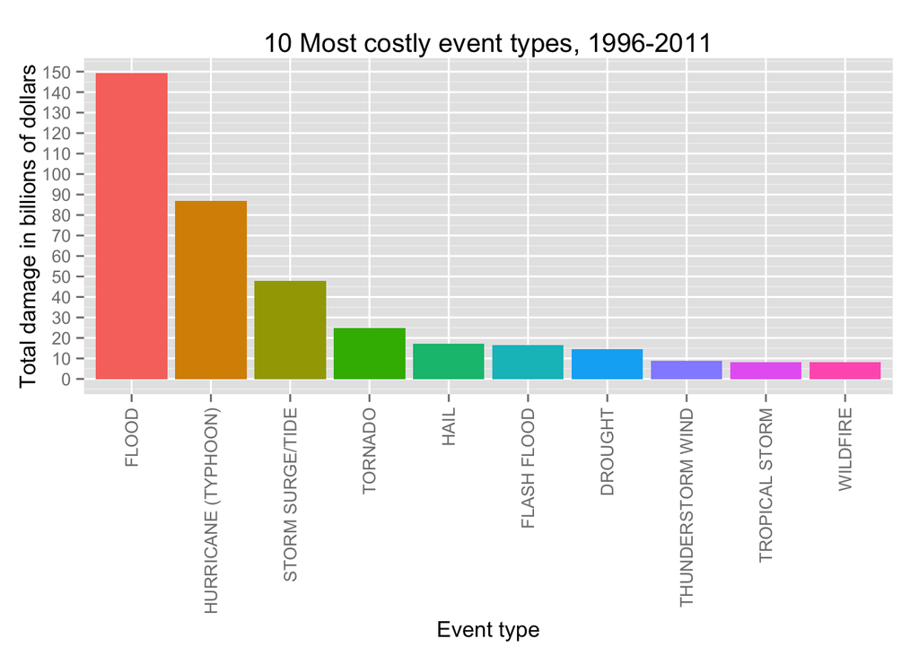

```r
library(ggplot2)
g <- ggplot(dmg.top, aes(dmg.top$event, dmg.top$tdmg))
g <- g + geom_bar(aes(fill=event), stat="identity")
g <- g + theme(axis.text.x=element_text(angle=90,hjust=1,vjust=0.5))
g <- g + xlab("Event type") + ylab("Total damage in billions of dollars")
g <- g + ggtitle("10 Most costly event types, 1996-2011") + theme(legend.position = "none")
g <- g + scale_y_continuous(breaks = seq(0,160,by = 10))
print(g)
```

### Most dangerous events

The data can be processed to find the most dangerous events. The data is aggregated by total casualties and sorted. The ten event types with the highest casualties can be selected.

```r
data.cas <- subset(data.a, data.a$casualties > 0)
cas <- aggregate(casualties ~ event, data = data.cas, sum)
cas$event <- factor(cas$event)
cas$casualties <- round(cas$casualties / 1000, 2)
cas <- cas[order(cas$casualties, decreasing=TRUE), ]
cas.top <- cas[1:10, ]
cas.top$event <- reorder(cas.top$event, -cas.top$casualties)
```

```
## [1] "Total casualties in thousands of casualties"
```

|  | event | casualties |
| --- | --- | --- |
| 34 | TORNADO | 23.33 |
| 11 | EXCESSIVE HEAT | 8.67 |
| 14 | FLOOD | 7.31 |
| 33 | THUNDERSTORM WIND | 5.99 |
| 25 | LIGHTNING | 5.36 |
| 18 | HEAT | 3.52 |
| 13 | FLASH FLOOD | 2.69 |
| 38 | WILDFIRE | 1.54 |
| 39 | WINTER STORM | 1.51 |
| 23 | HURRICANE (TYPHOON) | 1.47 |

```
##                  event casualties
## 34             TORNADO      23.33
## 11      EXCESSIVE HEAT       8.67
## 14               FLOOD       7.31
## 33   THUNDERSTORM WIND       5.99
## 25           LIGHTNING       5.36
## 18                HEAT       3.52
## 13         FLASH FLOOD       2.69
## 38            WILDFIRE       1.54
## 39        WINTER STORM       1.51
## 23 HURRICANE (TYPHOON)       1.47
```

The most dangerous events can now be plotted.

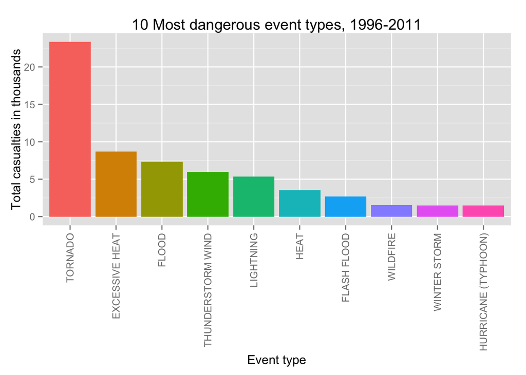

```r
g <- ggplot(cas.top, aes(cas.top$event, cas.top$casualties))
g <- g + geom_bar(aes(fill=event), stat="identity")
g <- g + theme(axis.text.x=element_text(angle=90,hjust=1,vjust=0.5))
g <- g + xlab("Event type") + ylab("Total casualties in thousands") + theme(legend.position = "none")
g <- g + ggtitle("10 Most dangerous event types, 1996-2011")
g <- g + scale_y_continuous(breaks = seq(0,25,by = 5))
print(g)
```

## Appendix: translation list

The text file is read with the separator specified as semi-colon. The semi-colon was used because it does not appear in the file. The objective is to read the file as a table with one field, which contains an entire line of the text file. The contents of the table are shown below, so the reader may reproduce all of the *event* translations that are used in this analysis.

```
## [1] "List of 48 SDP event types and alternate versions to be translated:"
```

```r
## The separator ";" is used because it does not appear in the file.
events_comma <- read.table("storm_events_list.txt", sep = ";")
kable(events_comma)
```

## V1

Astronomical Low Tide  
Avalanche  
Blizzard, heavy snow/blizzard, ground blizzard, blizzard/winter storm  
Coastal Flood, erosion/cstl flood, coastal flood/erosion, coastal flood/erosion, tidal flood, heavy surf coastal flood, coastal surge, astronomical high tide  
Cold/Wind Chill  
Debris Flow, landslide, landslides, mudslide, mud slide, rock slide, mudslide, mud slides  
Dense Fog, fog  
Dense Smoke  
Drought, heat wave drought, drought/excessive heat  
Dust Devil, landspout  
Dust Storm, dust storm/high wind  
Excessive Heat, extreme heat  
Extreme Cold/Wind Chill, extreme cold, extreme windchill, cold, extreme wind chill, extended cold, unseasonably cold  
Flash Flood, flood flash, flood/flashflood, flood/flash, flood/flash/flood  
Flood, river flood, urban/sml stream fld, river flooding, lake flood  
Frost/Freeze, frost, freeze, damaging freeze, frost\freeze, early frost, agricultural freeze, hard freeze  
Funnel Cloud  
Freezing Fog  
Hail, small hail, hail 100, hailstorm, hail 450, hail 175, hail 150, hail 75, hail 0.75, hail damage, marine hail  
Heat, heat wave, unseasonably warm  
Heavy Rain, heavy rain/high surf, urban flood, heavy rain/flood, heavy rain/severe weather, severe thunderstorm, flood/rain/wind, unseasonal rain, urban and small, urban small, urban/small stream flood, heavy shower, urban/small stream, small stream flood, heavy rain/small stream urban, river and stream flood, urban and small stream floodin  
Heavy Snow, blowing snow, excessive snow  
High Surf, heavy surf/high surf, rough surf, heavy surf  
High Wind, high wind/cold, high wind, high wind/, high wind damage  
Hurricane (Typhoon), typhoon, hurricane, hurricane/typhoon  
Ice Storm, icy roads, glaze ice, ice roads, glaze, black ice, glaze/ice storm, ice on road, ice roads  
Lake-Effect Snow  
Lakeshore Flood  
Lightning, lightningm, ligntning, lighting, lightning wauseon  
Marine Hail  
Marine High Wind, marine accident, high seas, rough seas  
Marine Strong Wind  
Marine Thunderstorm Wind, marine tstm wind  
Rip Current, rip currents  
Seiche  
Sleet, winter weather/mix, freezing drizzle  
Storm Surge/Tide, storm surge  
Strong Wind, strong winds, wind  
Thunderstorm Wind, tstm wind, thunderstormwind, thunderstorm wind53, thunderstorm wins, thunderstormw, thunderstrom wind, thundertorm wind, tunderstorm wind, thunderstorm wind g50, thunderstorm wind, thunderstorm wind 40, thundeerstorm wind, thunderstorm wind, thunderstorm wind/, trees, gustnado, microburst, dry microburst, wet microburst, microburst wind, severe thunderstorm wind, thunderestorm wind, thunderstorm wind/ tree, thunderstorm wind/awning, thunderstorm damage to, thunerstorm wind, thunderstorm wind., thunderstorm wind, dry microburst wind Tornado, cold air tornado, torndao  
Tropical Depression  
Tropical Storm  
Tsunami  
Volcanic Ash  
Waterspout, Waterspout/tornado, waterspout, tornado, waterspout-  
Wildfire, wild/forest fire, wild fires, wild/forest fires, wildfires, forest fires, grass fires, brush fire  
Winter Storm, winter storms, winter storm high wind, heavy snow and strong wind, snow and ice storm, sleet/ice storm, heavy snow/winter storm  
Winter Weather